# handling missing values

2025-01-24

Trying to handle the missing data

### The dataset

```r
d <- read_sav(here("outcomes paper/data_outcomes", "p_y_w1_for_analysesjan25.sav")) # 94 rows

# view_df(d)
```

```r
d1 <- d %>%
  select(school_id, family_id, participant_id, parent_eng_comf, youth_age, youth_gender, acadhwi_1, checkhwi_1, checkhwi_1, struct_1, convfut_1, knowschool_1, selfeffic_1, parnets_1, welcome_1, endorse_1, supported_1, ptrel_1, y_sch_eng, y_parsupp, y_parinv, y_hw, gen_grades, grades)

# view_df(d1)
```

```r
d2 <- d1 %>%
  mutate(parent_eng_comf = as.numeric(parent_eng_comf),
         youth_gender = factor(youth_gender),
         youth_age = as.numeric(youth_age))
# View(d2)
# view_df(d2)
```

```r
summary(d2)
```

```
##    school_id      family_id         participant_id     parent_eng_comf
##  Min.   :1.000   Length:94          Length:94          Min.   :1.000
##  1st Qu.:2.000   Class :character   Class :character   1st Qu.:2.000
##  Median :4.000   Mode  :character   Mode  :character   Median :2.500
##  Mean   :3.638                                         Mean   :2.733
##  3rd Qu.:5.000                                         3rd Qu.:4.000
##  Max.   :6.000                                         Max.   :5.000
##                                                        NA's   :8
##    youth_age     youth_gender   acadhwi_1       checkhwi_1       struct_1
##  Min.   :10.00   1:49         Min.   :1.000   Min.   :1.000   Min.   :1.625
##  1st Qu.:11.00   2:45         1st Qu.:2.286   1st Qu.:3.333   1st Qu.:2.750
##  Median :12.00                Median :2.714   Median :4.000   Median :3.000
##  Mean   :12.01                Mean   :2.713   Mean   :3.584   Mean   :2.942
##  3rd Qu.:13.00                3rd Qu.:3.143   3rd Qu.:4.000   3rd Qu.:3.125
##  Max.   :13.00                Max.   :4.000   Max.   :4.000   Max.   :4.000
##  NA's   :1                    NA's   :1       NA's   :1
##    convfut_1      knowschool_1    selfeffic_1      parnets_1
##  Min.   :1.000   Min.   :1.000   Min.   :2.200   Min.   :1.000
##  1st Qu.:3.000   1st Qu.:2.750   1st Qu.:3.000   1st Qu.:2.000
##  Median :3.333   Median :3.000   Median :3.000   Median :2.333
##  Mean   :3.225   Mean   :2.946   Mean   :3.122   Mean   :2.459
##  3rd Qu.:3.667   3rd Qu.:3.000   3rd Qu.:3.200   3rd Qu.:3.000
##  Max.   :4.000   Max.   :4.000   Max.   :4.000   Max.   :4.000
##
##    welcome_1       endorse_1      supported_1       ptrel_1
##  Min.   :2.250   Min.   :2.000   Min.   :2.000   Min.   :2.000
##  1st Qu.:3.000   1st Qu.:3.000   1st Qu.:3.000   1st Qu.:3.000
##  Median :3.000   Median :3.000   Median :3.000   Median :3.000
##  Mean   :3.146   Mean   :3.160   Mean   :3.154   Mean   :3.068
##  3rd Qu.:3.250   3rd Qu.:3.333   3rd Qu.:3.250   3rd Qu.:3.250
##  Max.   :4.000   Max.   :4.000   Max.   :4.000   Max.   :4.000
##
##    y_sch_eng       y_parsupp        y_parinv          y_hw
##  Min.   :2.333   Min.   :1.800   Min.   :1.000   Min.   :1.333
##  1st Qu.:3.667   1st Qu.:2.800   1st Qu.:2.250   1st Qu.:3.000
##  Median :4.000   Median :3.200   Median :3.000   Median :3.167
##  Mean   :4.028   Mean   :3.118   Mean   :2.783   Mean   :3.199
##  3rd Qu.:4.444   3rd Qu.:3.600   3rd Qu.:3.250   3rd Qu.:3.500
##  Max.   :5.000   Max.   :4.000   Max.   :4.000   Max.   :4.000
##
##    gen_grades        grades
##  Min.   :1.000   Min.   :1.000
##  1st Qu.:2.000   1st Qu.:2.000
##  Median :2.000   Median :2.000
##  Mean   :2.264   Mean   :2.389
##  3rd Qu.:2.000   3rd Qu.:3.000
##  Max.   :6.000   Max.   :7.000
##  NA's   :3       NA's   :4
```

# Inspect missingness patterns

outcomes with no NA: y_sch_eng  
y_parsupp y_parinv  
y_hw selfeffic_1

predictors with no NA: youth_gender struct_1 convfut_1 knowschool_1 parnets_1 welcome_1 endorse_1  
supported_1  
ptrel_1

This figure shows: 80 rows have no missing values 5 rows are missing parent_eng_comf 1 row is missing grades 3 rows are missing grades and parent_eng_comf 3 rows are missing gen_grades 1 row is missing acadhwi_1 and checkhwi_1 1 row is missing youth_age

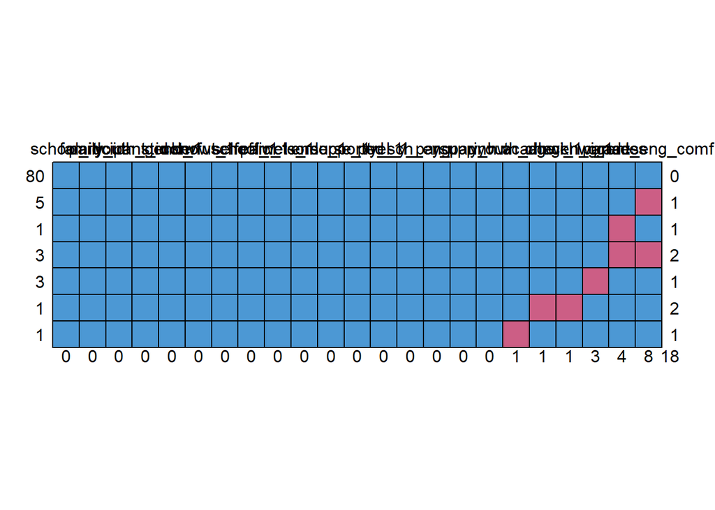

```
##    school_id family_id participant_id youth_gender struct_1 convfut_1
## 80         1         1              1            1        1         1
## 5          1         1              1            1        1         1
## 1          1         1              1            1        1         1
## 3          1         1              1            1        1         1
## 3          1         1              1            1        1         1
## 1          1         1              1            1        1         1
## 1          1         1              1            1        1         1
##            0         0              0            0        0         0
##    knowschool_1 selfeffic_1 parnets_1 welcome_1 endorse_1 supported_1 ptrel_1
## 80            1           1         1         1         1           1       1
## 5             1           1         1         1         1           1       1
## 1             1           1         1         1         1           1       1
## 3             1           1         1         1         1           1       1
## 3             1           1         1         1         1           1       1
```

[output cut: 21 more lines]

```r
md.pattern(d2)
```

# Inspect missingness proportions

This plot shows proportion of missingness: 85% is not missing

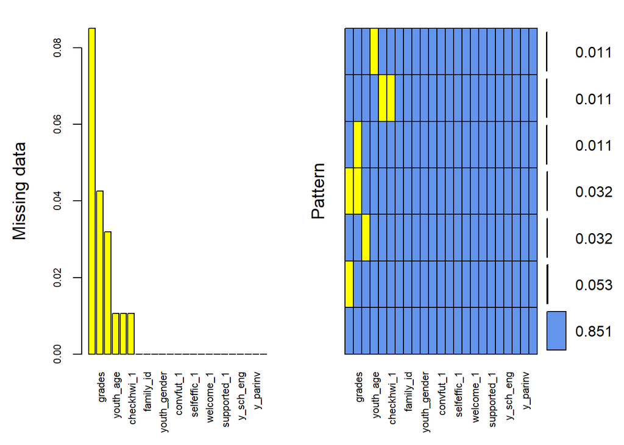

```
##
##  Variables sorted by number of missings:
##         Variable      Count
##  parent_eng_comf 0.08510638
##           grades 0.04255319
##       gen_grades 0.03191489
##        youth_age 0.01063830
##        acadhwi_1 0.01063830
##       checkhwi_1 0.01063830
##        school_id 0.00000000
##        family_id 0.00000000
##   participant_id 0.00000000
##     youth_gender 0.00000000
##         struct_1 0.00000000
##        convfut_1 0.00000000
##     knowschool_1 0.00000000
##      selfeffic_1 0.00000000
##        parnets_1 0.00000000
##        welcome_1 0.00000000
##        endorse_1 0.00000000
##      supported_1 0.00000000
##          ptrel_1 0.00000000
##        y_sch_eng 0.00000000
##        y_parsupp 0.00000000
##         y_parinv 0.00000000
##             y_hw 0.00000000
```

```r
nice_plot <- aggr(d2, col = c ('cornflowerblue', 'yellow'),
                  numbers = TRUE, sortVars = TRUE,
                  labels = names (d2), cex.axis = .7,
                  gap = 4, ylab = c ("Missing data", "Pattern"))
```

# Create a missingness or margin plot to further inspect missingness

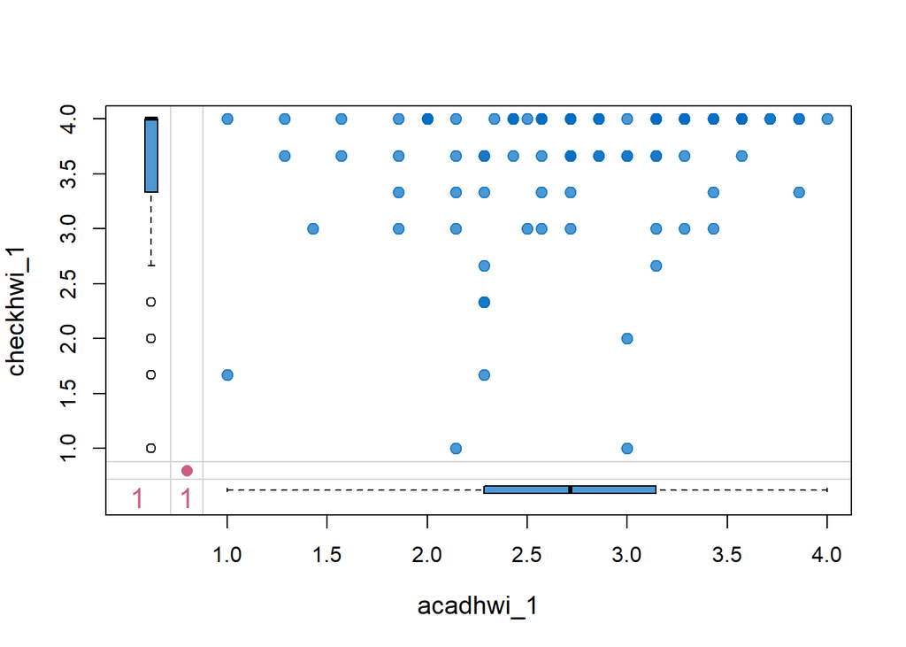

```r
marginplot(d2[, c("acadhwi_1", "checkhwi_1")], col = mdc(1:2), cex = 1.2, cex.lab = 1.2, cex.numbers = 1.3, pch = 19) # only 2 variables at a time
```

# Perform Little’s MCAR test

Get this error message: Error in TestMCARNormality(d2) :More than one missing data pattern should be present.

```r
library(RNOmni)  # Alternative package since BaylorEdPsych is unavailable
# TestMCARNormality(d2)
```

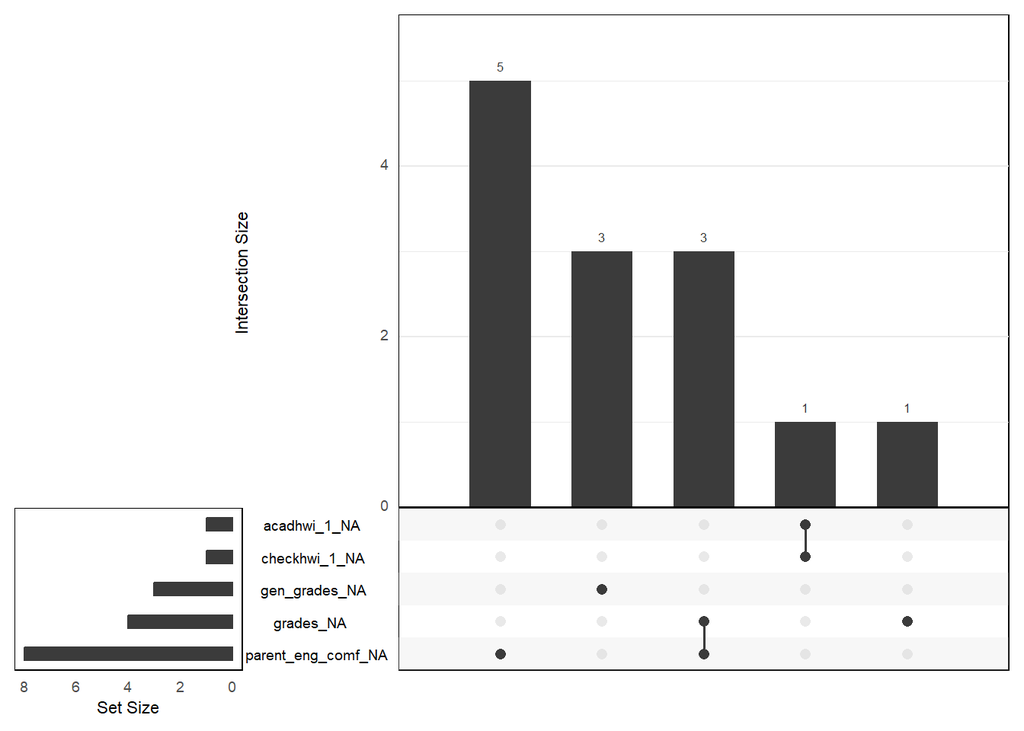

```r
library(naniar)
gg_miss_upset(d2)
```

I used this gg_miss_upset(mydata). Please, help me understand the plot.

### Imputation preprocessing

Following this instructions: https://library.virginia.edu/data/articles/getting-started-with-multiple-imputation-in-r

This person suggest to remove variables that have more than 25% misingness, character variables, and to remove variables that are highly correlated with others as that might mess up the imputations. Also they suggest not make any transformations at this point.

# Specify a separate imputation model for variables of interest is they are not numerical (code from link above)

# Ordered categorical variables

poly <- c(“patriot_amident”, “pid_x”)